# **Milestone 1**

### **The key questions:**

- What are the key questions that need to be answered?
  - Are there particular attributes of a car that can lead to a particular price point?
  - Do certain car models or brands really sell differently when they are used or are they all priced similarly?
  - What is a price that our sellers can offer to the customer that will maximize our profits but also maximize the utility of the customer?

## **Data Dictionary**

**S.No.** : Serial Number

**Name** : Name of the car which includes Brand name and Model name

**Location** : The location in which the car is being sold or is available for purchase (Cities)

**Year** : Manufacturing year of the car

**Kilometers_driven** : The total kilometers driven in the car by the previous owner(s) in KM

**Fuel_Type** : The type of fuel used by the car (Petrol, Diesel, Electric, CNG, LPG)

**Transmission** : The type of transmission used by the car (Automatic / Manual)

**Owner** : Type of ownership

**Mileage** : The standard mileage offered by the car company in kmpl or km/kg

**Engine** : The displacement volume of the engine in CC

**Power** : The maximum power of the engine in bhp

**Seats** : The number of seats in the car

**New_Price** : The price of a new car of the same model in INR 100,000

**Price** : The price of the used car in INR 100,000 (**Target Variable**)

## **Important Notes**

- This notebook can be considered a guide to refer to while solving the problem. The evaluation will be as per the Rubric shared for each Milestone. Unlike previous courses, it does not follow the pattern of the graded questions in different sections. This notebook will give you a direction on what steps need to be taken in order to get a viable solution to the problem. Please note that this is just one way of doing this. There can be other 'creative' ways to solve the problem and we urge you to feel free and explore them as an 'optional' exercise.
- In the notebook, there are markdown cells called - Observations and Insights. It is a good practice to provide observations and extract insights from the outputs.
- The naming convention for different variables can vary. Please consider the code provided in this notebook as a sample code.
- All the outputs in the notebook are just for reference and can be different if you follow a different approach.
- There are sections called **Think About It** in the notebook that will help you get a better understanding of the reasoning behind a particular technique/step. Interested learners can take alternative approaches if they wish to explore different techniques.

# **Milestone 1**

### **Loading libraries**

```python
# Import required libraries
import pandas as pd
import numpy as np

import matplotlib.pyplot as plt
import seaborn as sns

# To ignore warnings
import warnings
warnings.filterwarnings('ignore')

# Remove the limit from the number of displayed columns and rows. It helps to see the entire dataframe while printing it
pd.set_option("display.max_columns", None)
```

### **Let us load the data**

```python
data = pd.read_csv("used_cars.csv")
```

### **Understand the data by observing a few rows**

```python
data.head()
```

|  | S.No. | Name | Location | Year | Kilometers_Driven | Fuel_Type | Transmission | Owner_Type | Mileage | Engine | Power | Seats | New_price | Price |
| --- | --- | --- | --- | --- | --- | --- | --- | --- | --- | --- | --- | --- | --- | --- |
| 0 | 0 | Maruti Wagon R LXI CNG | Mumbai | 2010 | 72000 | CNG | Manual | First | 26.60 | 998.0 | 58.16 | 5.0 | NaN | 1.75 |
| 1 | 1 | Hyundai Creta 1.6 CRDi SX Option | Pune | 2015 | 41000 | Diesel | Manual | First | 19.67 | 1582.0 | 126.20 | 5.0 | NaN | 12.50 |
| 2 | 2 | Honda Jazz V | Chennai | 2011 | 46000 | Petrol | Manual | First | 18.20 | 1199.0 | 88.70 | 5.0 | 8.61 | 4.50 |
| 3 | 3 | Maruti Ertiga VDI | Chennai | 2012 | 87000 | Diesel | Manual | First | 20.77 | 1248.0 | 88.76 | 7.0 | NaN | 6.00 |
| 4 | 4 | Audi A4 New 2.0 TDI Multitronic | Coimbatore | 2013 | 40670 | Diesel | Automatic | Second | 15.20 | 1968.0 | 140.80 | 5.0 | NaN | 17.74 |

```python
data.tail()
```

|  | S.No. | Name | Location | Year | Kilometers_Driven | Fuel_Type | Transmission | Owner_Type | Mileage | Engine | Power | Seats | New_price | Price |
| --- | --- | --- | --- | --- | --- | --- | --- | --- | --- | --- | --- | --- | --- | --- |
| 7248 | 7248 | Volkswagen Vento Diesel Trendline | Hyderabad | 2011 | 89411 | Diesel | Manual | First | 20.54 | 1598.0 | 103.6 | 5.0 | NaN | NaN |
| 7249 | 7249 | Volkswagen Polo GT TSI | Mumbai | 2015 | 59000 | Petrol | Automatic | First | 17.21 | 1197.0 | 103.6 | 5.0 | NaN | NaN |
| 7250 | 7250 | Nissan Micra Diesel XV | Kolkata | 2012 | 28000 | Diesel | Manual | First | 23.08 | 1461.0 | 63.1 | 5.0 | NaN | NaN |
| 7251 | 7251 | Volkswagen Polo GT TSI | Pune | 2013 | 52262 | Petrol | Automatic | Third | 17.20 | 1197.0 | 103.6 | 5.0 | NaN | NaN |
| 7252 | 7252 | Mercedes-Benz E-Class 2009-2013 E 220 CDI Avan... | Kochi | 2014 | 72443 | Diesel | Automatic | First | 10.00 | 2148.0 | 170.0 | 5.0 | NaN | NaN |

**Observations and Insights:**

We observe that there are 7253 rows within this data set and 14 variables that we want to consider for this analysis. We can also see that there are a good portion of the New_price variable and Price variable do not have a numerical observatoin. We will have consider alternatives of handling missing values

### **Let us check the data types and and missing values of each column**

```python
# Check the datatypes of each column. Hint: Use info() method
data.info()
```

```
<class 'pandas.core.frame.DataFrame'>
RangeIndex: 7253 entries, 0 to 7252
Data columns (total 14 columns):
 #   Column             Non-Null Count  Dtype
---  ------             --------------  -----
 0   S.No.              7253 non-null   int64
 1   Name               7253 non-null   object
 2   Location           7253 non-null   object
 3   Year               7253 non-null   int64
 4   Kilometers_Driven  7253 non-null   int64
 5   Fuel_Type          7253 non-null   object
 6   Transmission       7253 non-null   object
 7   Owner_Type         7253 non-null   object
 8   Mileage            7251 non-null   float64
 9   Engine             7207 non-null   float64
 10  Power              7078 non-null   float64
 11  Seats              7200 non-null   float64
 12  New_price          1006 non-null   float64
 13  Price              6019 non-null   float64
dtypes: float64(6), int64(3), object(5)
memory usage: 793.4+ KB
```

```python
# Check total number of missing values of each column. Hint: Use isnull() method
data.isnull().sum()
```

```
S.No.                   0
Name                    0
Location                0
Year                    0
Kilometers_Driven       0
Fuel_Type               0
Transmission            0
Owner_Type              0
Mileage                 2
Engine                 46
Power                 175
Seats                  53
New_price            6247
Price                1234
dtype: int64
```

**Observations and Insights:**

- We observe that mileage has two missing values, engine has 46 missing values, power has 175 missing values, seats has 53 missing values, New_Price has 6,247 missing values, and Price has 1234 missing values.
- Name, location, Fuel_Type, Trasmission, and Owner_Type are all objects(strings)
- S.No., Year, Kilometers_Driven are integers
  - S.No. and Year should be considered objects in my opinion (Strings) or categorical variables
- Mileage, Engine, Power, Seats, New_Price, and Price are Float types
  - Seats should be considered an integer and may need to be changed

We can observe that `S.No.` has no null values. Also the number of unique values are equal to the number of observations. So, `S.No.` looks like an index for the data entry and such a column would not be useful in providing any predictive power for our analysis. Hence, it can be dropped.

```python
# Remove S.No. column from data. Hint: Use inplace = True
data.drop(columns = ['S.No.'], inplace = True)
```

## **Exploratory Data Analysis**

### **Let us now explore the summary statistics of numerical variables**

```python
# Explore basic summary statistics of numeric variables. Hint: Use describe() method.
data.describe().T
```

|  | count | mean | std | min | 25% | 50% | 75% | max |
| --- | --- | --- | --- | --- | --- | --- | --- | --- |
| Year | 7253.0 | 2013.365366 | 3.254421 | 1996.00 | 2011.000 | 2014.00 | 2016.0000 | 2019.00 |
| Kilometers_Driven | 7253.0 | 58699.063146 | 84427.720583 | 171.00 | 34000.000 | 53416.00 | 73000.0000 | 6500000.00 |
| Mileage | 7251.0 | 18.141580 | 4.562197 | 0.00 | 15.170 | 18.16 | 21.1000 | 33.54 |
| Engine | 7207.0 | 1616.573470 | 595.285137 | 72.00 | 1198.000 | 1493.00 | 1968.0000 | 5998.00 |
| Power | 7078.0 | 112.765214 | 53.493553 | 34.20 | 75.000 | 94.00 | 138.1000 | 616.00 |
| Seats | 7200.0 | 5.280417 | 0.809277 | 2.00 | 5.000 | 5.00 | 5.0000 | 10.00 |
| New_price | 1006.0 | 22.779692 | 27.759344 | 3.91 | 7.885 | 11.57 | 26.0425 | 375.00 |
| Price | 6019.0 | 9.479468 | 11.187917 | 0.44 | 3.500 | 5.64 | 9.9500 | 160.00 |

**Observations and Insights:**

- Year appears to have a min of 1996 with a max of 2019 and an median and mean that are close to each other. I dont think year should be an integar, its more of a categorical variable in my opinion
- Kilometers_Driven does not appear to fulfill the central limit theorom with a mean and median that is drastically different caused by the extremely high maximum entry compared and a siginificantly large range as well as a std that is larger than the mean
- Milage appears to flow the central limit therom with an a range around 34 km/liter
- Power does not satisfy the central limit therom with a range of approximately 580 and a mean that is larger than the median. The maximum distance between the 75 percentile is significantly large
- Seats have a range of 8 and a mean and median that are relatively close to one another. There is a significant jump from the 75 percentile to the max making it appear that this distribution is right skewed
- New Price is right skewed with a maximum that is almost 350 INR more than the 75 percentile and a mean and median that are not similar which does not satify the central limit therom

### **Let us also explore the summary statistics of all categorical variables and the number of unique observations in each category**

```python
# Explore basic summary statistics of categorical variables. Hint: Use the argument include = ['object']
data.describe(include='object').T
```

|  | count | unique | top | freq |
| --- | --- | --- | --- | --- |
| Name | 7253 | 2041 | Mahindra XUV500 W8 2WD | 55 |
| Location | 7253 | 11 | Mumbai | 949 |
| Fuel_Type | 7253 | 5 | Diesel | 3852 |
| Transmission | 7253 | 2 | Manual | 5204 |
| Owner_Type | 7253 | 4 | First | 5952 |

**Number of unique observations in each category**

```python
cat_cols = data.select_dtypes(include = ['object']).columns

for column in cat_cols:

    print("For column:", column)

    print(data[column].nunique())

    print('-'*50)
```

```
For column: Name
2041
--------------------------------------------------
For column: Location
11
--------------------------------------------------
For column: Fuel_Type
5
--------------------------------------------------
For column: Transmission
2
--------------------------------------------------
For column: Owner_Type
4
--------------------------------------------------
```

#### **Observations and Insights:**

- There are 2041 unique brand names and model names of cars within this data set
- There are 11 unique locations that these used cars are being sold within this data set
- There are 5 unique fuel types for the cars being used in the data set
- There are 2 unique transmissions for these cars within the data set
- There are 4 unique ownerhship types for this data set as well

**Think About It**:

- We could observe from summary statistics that kilometers_driven has extreme values. Can we look at the manufactured year for cars with extreme values for kilometers_driven?
- Also, we could observe the feature mileage has values zero. Can the mileage of a car be zero?

**Let's explore the two points mentioned above**

**Check Kilometers_Driven extreme values**

```python
# Sort the dataset in 'descending' order using the feature 'Kilometers_Driven'
data.sort_values(by = 'Kilometers_Driven', ascending = False).head(10)
```

|  | Name | Location | Year | Kilometers_Driven | Fuel_Type | Transmission | Owner_Type | Mileage | Engine | Power | Seats | New_price | Price |
| --- | --- | --- | --- | --- | --- | --- | --- | --- | --- | --- | --- | --- | --- |
| 2328 | BMW X5 xDrive 30d M Sport | Chennai | 2017 | 6500000 | Diesel | Automatic | First | 15.97 | 2993.0 | 258.00 | 5.0 | NaN | 65.00 |
| 340 | Skoda Octavia Ambition Plus 2.0 TDI AT | Kolkata | 2013 | 775000 | Diesel | Automatic | First | 19.30 | 1968.0 | 141.00 | 5.0 | NaN | 7.50 |
| 1860 | Volkswagen Vento Diesel Highline | Chennai | 2013 | 720000 | Diesel | Manual | First | 20.54 | 1598.0 | 103.60 | 5.0 | NaN | 5.90 |
| 358 | Hyundai i10 Magna 1.2 | Chennai | 2009 | 620000 | Petrol | Manual | First | 20.36 | 1197.0 | 78.90 | 5.0 | NaN | 2.70 |
| 2823 | Volkswagen Jetta 2013-2015 2.0L TDI Highline AT | Chennai | 2015 | 480000 | Diesel | Automatic | First | 16.96 | 1968.0 | 138.03 | 5.0 | NaN | 13.00 |
| 3092 | Honda City i VTEC SV | Kolkata | 2015 | 480000 | Petrol | Manual | First | 17.40 | 1497.0 | 117.30 | 5.0 | NaN | 5.00 |
| 4491 | Hyundai i20 Magna Optional 1.2 | Bangalore | 2013 | 445000 | Petrol | Manual | First | 18.50 | 1197.0 | 82.90 | 5.0 | NaN | 4.45 |
| 6921 | Maruti Swift Dzire Tour LDI | Jaipur | 2012 | 350000 | Diesel | Manual | First | 23.40 | 1248.0 | 74.00 | 5.0 | NaN | NaN |
| 3649 | Tata Indigo LS | Jaipur | 2008 | 300000 | Diesel | Manual | First | 17.00 | 1405.0 | 70.00 | 5.0 | NaN | 1.00 |
| 1528 | Toyota Innova 2.5 G (Diesel) 8 Seater BS IV | Hyderabad | 2005 | 299322 | Diesel | Manual | First | 12.80 | 2494.0 | 102.00 | 8.0 | NaN | 4.00 |

#### **Observations and Insights:**

- Row 2328 has driven their BMW X5 xDrive 30d M Sport 6,500,000 Kilometers. This appears to be a typo and somehting that we do not consider to be possible so we will remove this observation
- All of these vehicles that have high mileage all have an owner type of first meaning these cars have only had one previous owner
- The top nine observations are 5 seat vehicles
- The top 10 kilometers driven cars are either diesel or petrol cars
- Seven of the 10 highest driven cares are manual cars while the other three are automatic transmissions

In the first row, a car manufactured as recently as 2017 having been driven 6500000 km is almost impossible. It can be considered as data entry error and so we can remove this value/entry from data.

```python
# Removing the 'row' at index 2328 from the data. Hint: use the argument inplace=True
data.drop([2328], inplace = True)
```

**Check Mileage extreme values**

```python
# Sort the dataset in 'ascending' order using the feature 'Mileage'
data.sort_values(by = 'Mileage', ascending = True).head(10)
```

|  | Name | Location | Year | Kilometers_Driven | Fuel_Type | Transmission | Owner_Type | Mileage | Engine | Power | Seats | New_price | Price |
| --- | --- | --- | --- | --- | --- | --- | --- | --- | --- | --- | --- | --- | --- |
| 2597 | Hyundai Santro Xing XP | Pune | 2007 | 70000 | Petrol | Manual | First | 0.0 | 1086.0 | NaN | 5.0 | NaN | 1.12 |
| 2343 | Hyundai Santro AT | Hyderabad | 2006 | 74483 | Petrol | Automatic | First | 0.0 | 999.0 | NaN | 5.0 | NaN | 2.30 |
| 5270 | Honda City 1.5 GXI | Bangalore | 2002 | 53000 | Petrol | Manual | Second | 0.0 | NaN | NaN | NaN | NaN | 1.85 |
| 424 | Volkswagen Jetta 2007-2011 1.9 L TDI | Hyderabad | 2010 | 42021 | Diesel | Manual | First | 0.0 | 1968.0 | NaN | 5.0 | NaN | 5.45 |
| 6857 | Land Rover Freelander 2 TD4 SE | Mumbai | 2011 | 87000 | Diesel | Automatic | First | 0.0 | 2179.0 | 115.0 | 5.0 | NaN | NaN |
| 443 | Hyundai Santro GLS I - Euro I | Coimbatore | 2012 | 50243 | Petrol | Manual | First | 0.0 | 1086.0 | NaN | 5.0 | NaN | 3.35 |
| 5119 | Hyundai Santro Xing XP | Kolkata | 2008 | 45500 | Petrol | Manual | Second | 0.0 | 1086.0 | NaN | 5.0 | NaN | 1.17 |
| 5022 | Land Rover Freelander 2 TD4 SE | Hyderabad | 2013 | 46000 | Diesel | Automatic | Second | 0.0 | 2179.0 | 115.0 | 5.0 | NaN | 26.00 |
| 5016 | Land Rover Freelander 2 TD4 HSE | Delhi | 2013 | 72000 | Diesel | Automatic | First | 0.0 | 2179.0 | 115.0 | 5.0 | NaN | 15.50 |
| 2542 | Hyundai Santro GLS II - Euro II | Bangalore | 2011 | 65000 | Petrol | Manual | Second | 0.0 | NaN | NaN | NaN | NaN | 3.15 |

#### **Observations**

- Mileage of cars can not be 0, so we should treat 0's as missing values. We will do it in the Feature Engineering part.

## **Univariate Analysis**

Univariate analysis is used to explore each variable in a data set, separately. It looks at the range of values, as well as the central tendency of the values. It can be done for both numerical and categorical variables.

## **1. Univariate Analysis - Numerical Data**

Histograms and box plots help to visualize and describe numerical data. We use box plot and histogram to analyse the numerical columns.

```python
# Let us write a function that will help us create a boxplot and histogram for any input numerical variable.
# This function takes the numerical column as the input and returns the boxplots and histograms for the variable.

def histogram_boxplot(feature, figsize = (15, 10), bins = None):

    """ Boxplot and histogram combined

    feature: 1-d feature array

    figsize: size of fig (default (9, 8))

    bins: number of bins (default None / auto)

    """
    f2, (ax_box2, ax_hist2) = plt.subplots(nrows = 2, # Number of rows of the subplot grid = 2
                                           sharex = True, # X-axis will be shared among all subplots
                                           gridspec_kw = {"height_ratios": (.25, .75)},
                                           figsize = figsize
                                           ) # Creating the 2 subplots

    sns.boxplot(feature, ax = ax_box2, showmeans = True, color = 'violet') # Boxplot will be created and a symbol will indicate the mean value of the column

    sns.distplot(feature, kde = F, ax = ax_hist2, bins = bins, palette = "winter") if bins else sns.distplot(feature, kde = False, ax = ax_hist2) # For histogram

    ax_hist2.axvline(np.mean(feature), color = 'green', linestyle = '--') # Add mean to the histogram

    ax_hist2.axvline(np.median(feature), color = 'black', linestyle = '-') # Add median to the histogram
```

**Let us plot histogram and box-plot for the feature 'Kilometers_Driven' to understand the distribution and outliers, if any.**

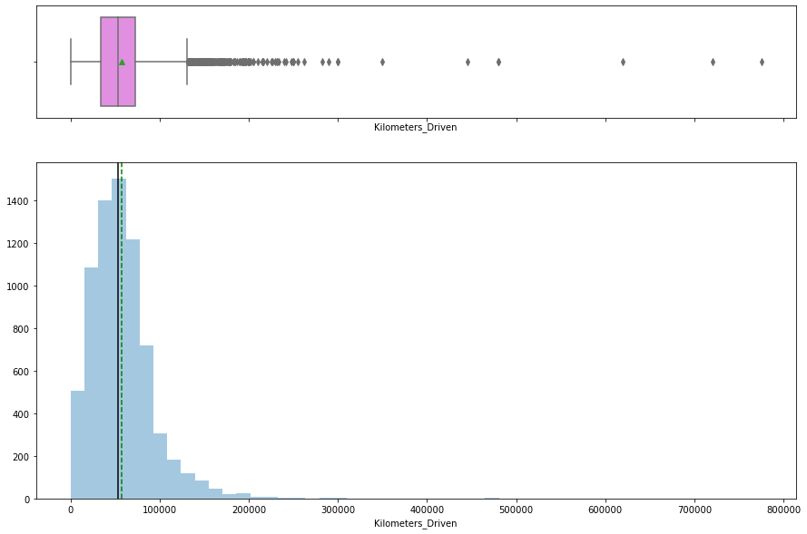

```python
# Plot histogram and box-plot for 'Kilometers_Driven'
histogram_boxplot(data['Kilometers_Driven'])
```

**Think About It**: Kilometers_Driven is highly right-skewed. Can we use Log transformation of the feature to reduce/remove the skewness? Why can't we keep skewed data?

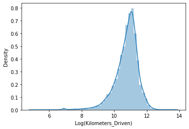

```python
# Log transformation of the feature 'Kilometers_Driven'
sns.distplot(np.log(data["Kilometers_Driven"]), axlabel = "Log(Kilometers_Driven)");
```

**Observations and Insights:**

```python
# We can add a transformed kilometers_driven feature in data
data["kilometers_driven_log"] = np.log(data["Kilometers_Driven"])
```

**Note:** Like Kilometers_Driven, the distribution of Price is also highly skewed, we can use log transformation on this column to see if that helps normalize the distribution. And add the transformed variable into the dataset. You can name the variable as **'price_log'**.

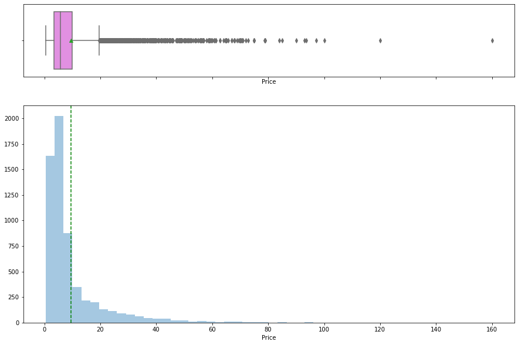

```python
# Plot histogram and box-plot for 'Price'
histogram_boxplot(data['Price'])
```

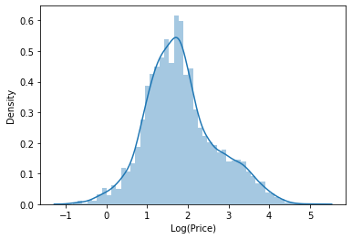

```python
# Log transformation of the feature 'Price'
sns.distplot(np.log(data['Price']), axlabel = 'Log(Price)')
```

```python
# We can Add a transformed Price feature in data
data['Price_log'] = np.log(data['Price'])
```

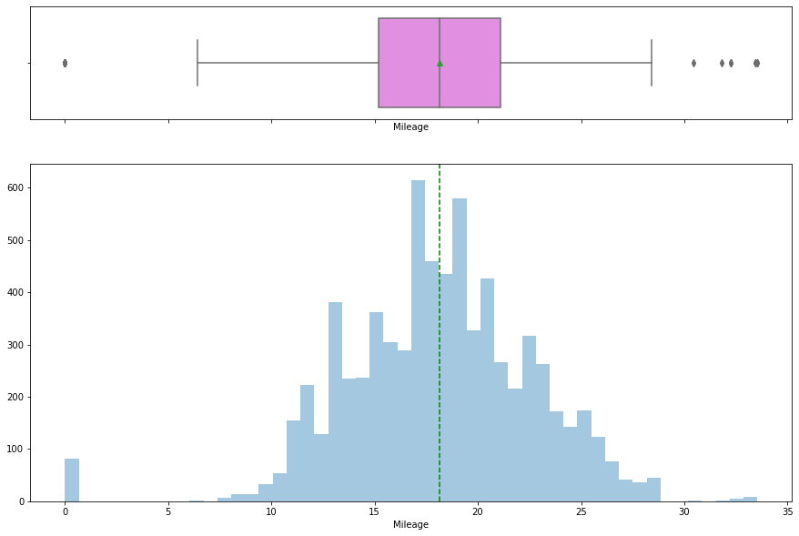

```python
# Plot histogram and box-plot for 'Mileage'
histogram_boxplot(data['Mileage'])
```

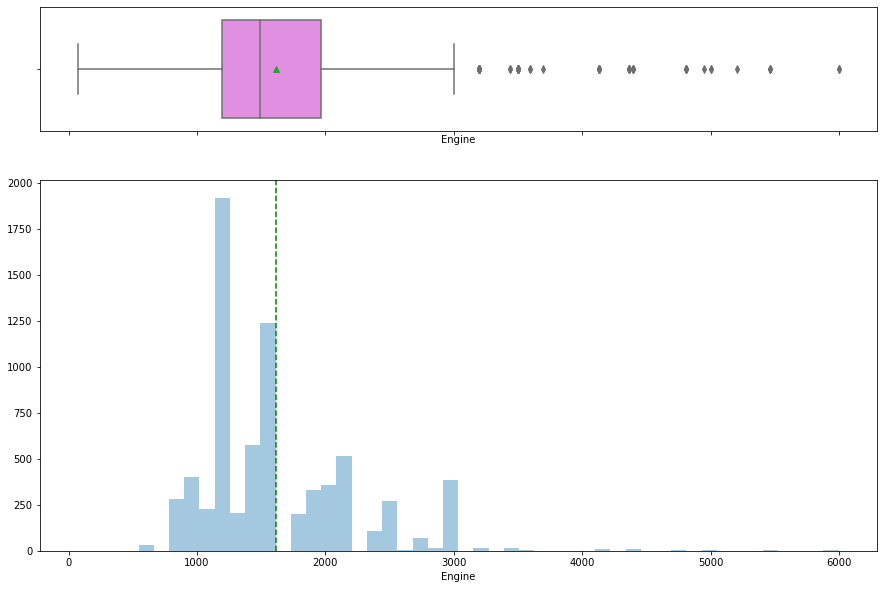

```python
# Plot histogram and box-plot for 'Engine'
histogram_boxplot(data['Engine'])
```

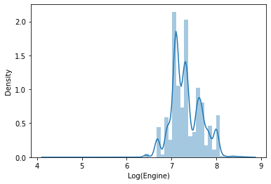

```python
# Log transformation of the feature 'Price'
sns.distplot(np.log(data['Engine']), axlabel = 'Log(Engine)')
```

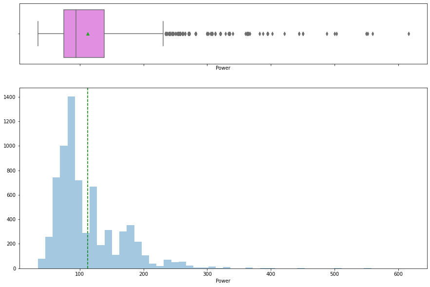

```python
# Plot histogram and box-plot for 'Power'
histogram_boxplot(data['Power'])
```

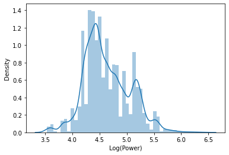

```python
# Log transformation of the feature 'Price'
sns.distplot(np.log(data['Power']), axlabel = 'Log(Power)')
```

```python
# We can Add a transformed Power feature in data
data['Power_log'] = np.log(data['Power'])
```

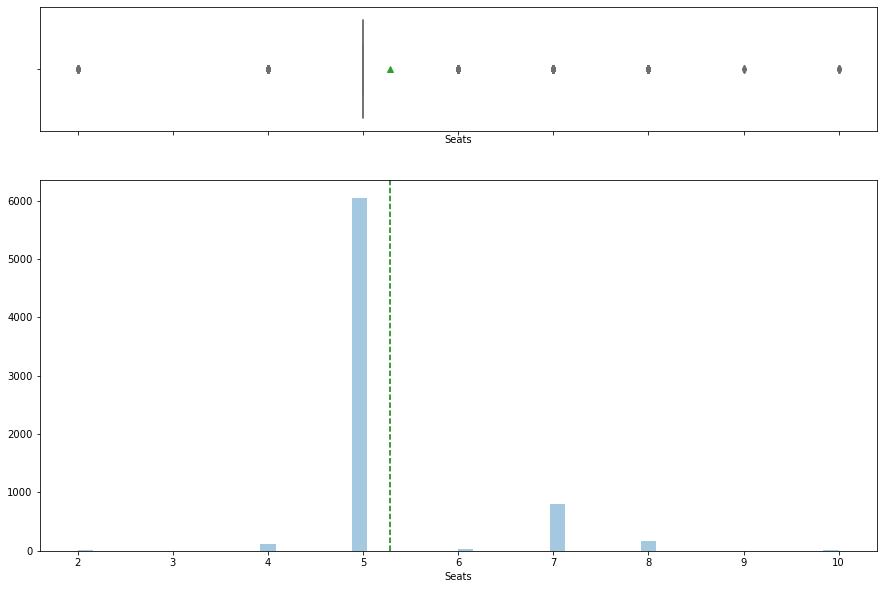

```python
# Plot histogram and box-plot for 'Seats'
histogram_boxplot(data['Seats'])
```

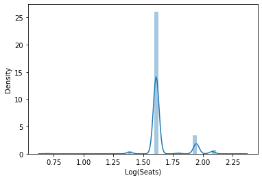

```python
# Log transformation of the feature 'Price'
sns.distplot(np.log(data['Seats']), axlabel = 'Log(Seats)')
```

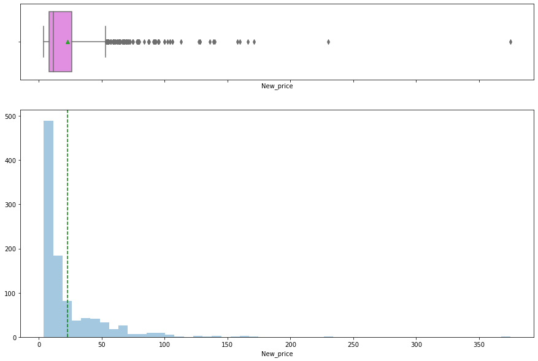

```python
# Plot histogram and box-plot for 'New_price'
histogram_boxplot(data['New_price'])
```

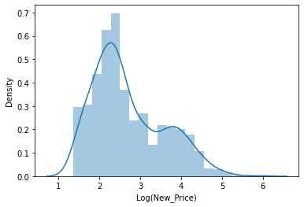

```python
# Log transformation of the feature 'Price'
sns.distplot(np.log(data['New_price']), axlabel = 'Log(New_Price)')
```

```python
# We can Add a transformed Price feature in data
data['New_Price_log'] = np.log(data['New_price'])
```

**Note:** Try plotting histogram and box-plot for different numerical features and understand how the data looks like.

**Observations and Insights for all the plots:**

- After examining all of the potential independent variables, we will take the log of Price, Power, and New Price in order to have these variables have a closer resemblance to a normal distribution since they do appear to have a skewed distribution. All of these variables are continuous and have a wide range that can throw off our error terms and possibly give us false negatives or false positives

## **2. Univariate analysis - Categorical Data**

```python
# Let us write a function that will help us create barplots that indicate the percentage for each category.
# This function takes the categorical column as the input and returns the barplots for the variable.

def perc_on_bar(z):
    '''
    plot
    feature: categorical feature
    the function won't work if a column is passed in hue parameter
    '''

    total = len(data[z]) # Length of the column

    plt.figure(figsize = (15, 5))

    ax = sns.countplot(data[z], palette = 'Paired', order = data[z].value_counts().index)

    for p in ax.patches:

        percentage = '{:.1f}%'.format(100 * p.get_height() / total) # Percentage of each class of the category

        x = p.get_x() + p.get_width() / 2 - 0.05 # Width of the plot

        y = p.get_y() + p.get_height()           # Hieght of the plot

        ax.annotate(percentage, (x, y), size = 12) # Annotate the percantage

    plt.show() # Show the plot
```

**Let us plot barplot for the variable location. It will be helpful to know the number of percentage of cars from each city.**

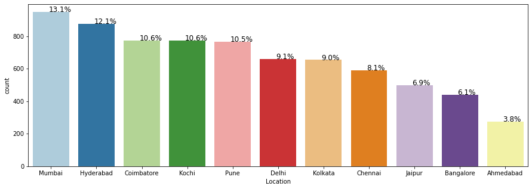

```python
# Bar Plot for 'Location'
perc_on_bar('Location')
```

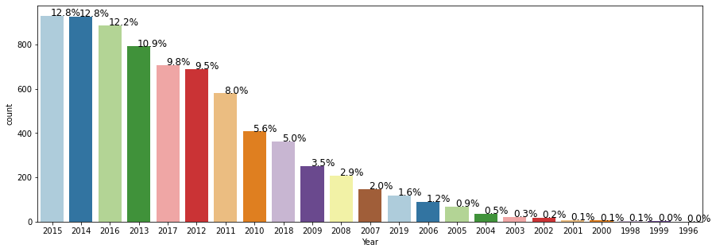

```python
# Bar Plot for 'YEAR'
perc_on_bar('Year')
```

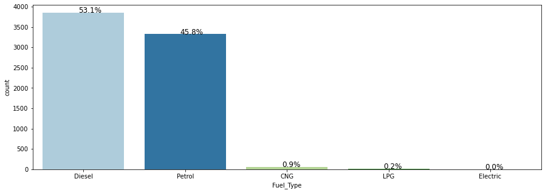

```python
# Bar Plot for 'Fuel_Type'
perc_on_bar('Fuel_Type')
```

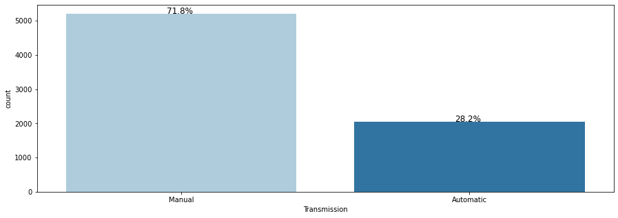

```python
# Bar Plot for 'Transmission'
perc_on_bar('Transmission')
```

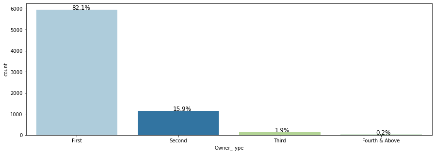

```python
# Bar Plot for 'Owner_Type'
perc_on_bar('Owner_Type')
```

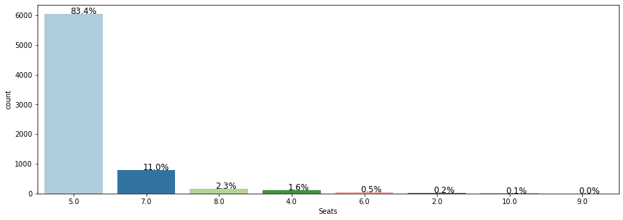

```python
# Bar Plot for 'Seats'
perc_on_bar('Seats')
```

**Note:** Explore for other variables like Year, Fuel_Type, Transmission, Owner_Type`.

**Observations and Insights from all plots:**

## **Bivariate Analysis**

### **1. Scatter plot**

A scatter plot allows us to see relationships between two variables.

**Note: Use log transformed values 'kilometers_driven_log' and 'price_log'**

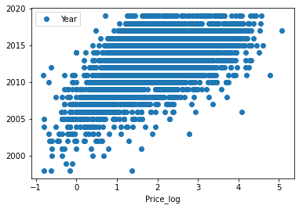

```python
# Let us plot pair plot for the variables 'year' and 'price_log'
data.plot(x = 'Price_log', y = 'Year', style = 'o')
```

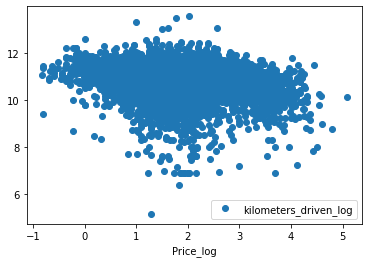

```python
# Let us plot pair plot for the variables 'kilometers_driven_log' and 'price_log'
data.plot(x = 'Price_log', y = 'kilometers_driven_log', style = 'o')
```

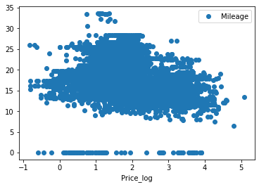

```python
# Let us plot pair plot for the variables 'Mileage' and 'price_log'
data.plot(x = 'Price_log', y = 'Mileage', style = 'o')
```

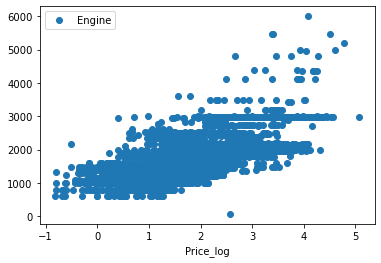

```python
# Let us plot pair plot for the variables 'Engine' and 'price_log'
data.plot(x = 'Price_log', y = 'Engine', style = 'o')
```

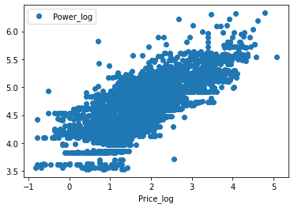

```python
# Let us plot pair plot for the variables 'Power' and 'price_log'
data.plot(x = 'Price_log', y = 'Power_log', style = 'o')
```

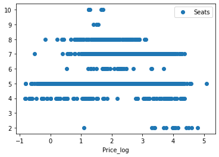

```python
# Let us plot pair plot for the variables 'Seats' and 'New_price'
data.plot(x = 'Price_log', y = 'Seats', style = 'o')
```

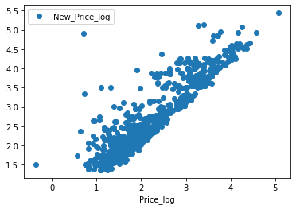

```python
# Let us plot pair plot for the variables 'New_price' and 'New_price'
data.plot(x = 'Price_log', y = 'New_Price_log', style = 'o')
```

**Note:** Try to explore different combinations of independent variables and dependent variable. Understand the relationship between all variables.

**Observations and Insights from all plots:**

### **2. Heat map**

Heat map shows a 2D correlation matrix between two numerical features.

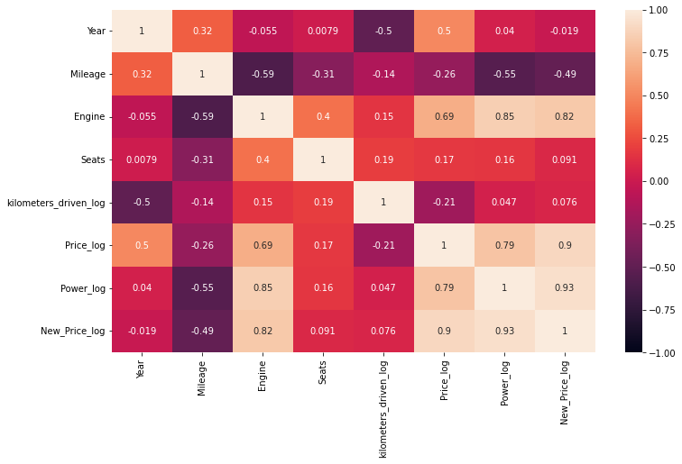

```python
# We can include the log transformation values and drop the original skewed data columns
plt.figure(figsize = (12, 7))

sns.heatmap(data.drop(['Price', 'Kilometers_Driven', 'Power', 'New_price'],axis = 1).corr(), annot = True, vmin = -1, vmax = 1)

plt.show()
```

**Observations and Insights:**